# Automating our work away

## Outline

### 1. About Darkhorse

### 2. Problems we faced

### 3. How we solved those problems

### 4. How you can improve R(Markdown) adoption

[figure not shown]

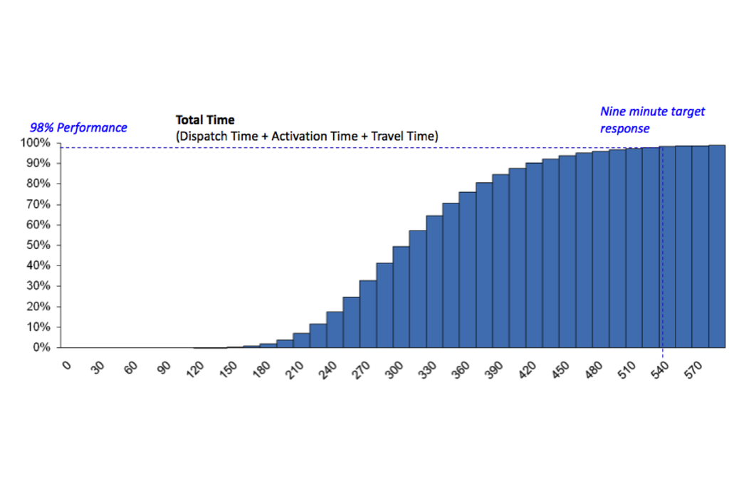

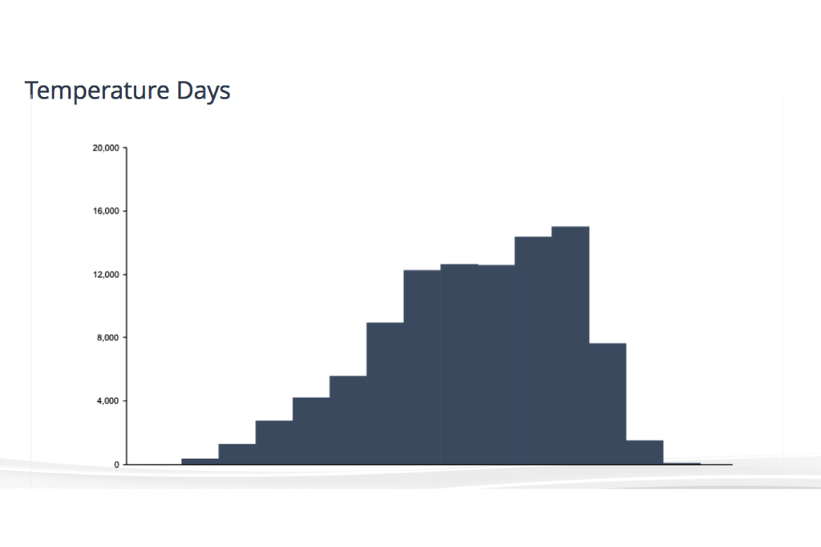

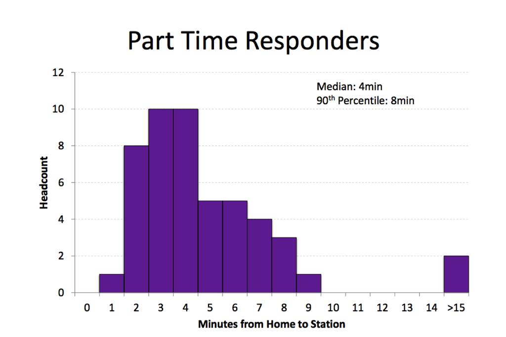

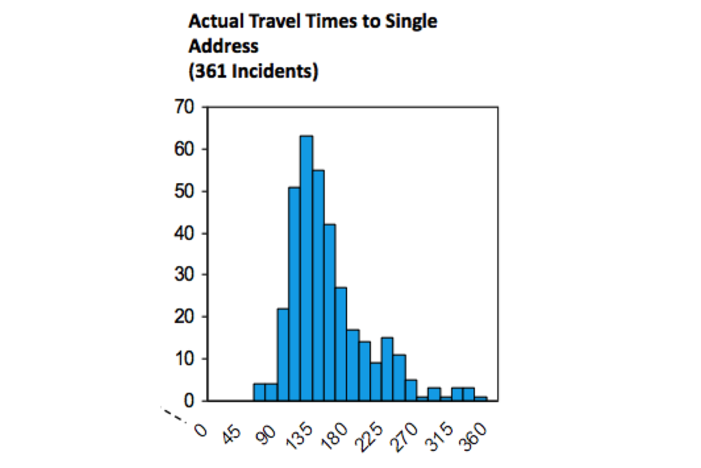

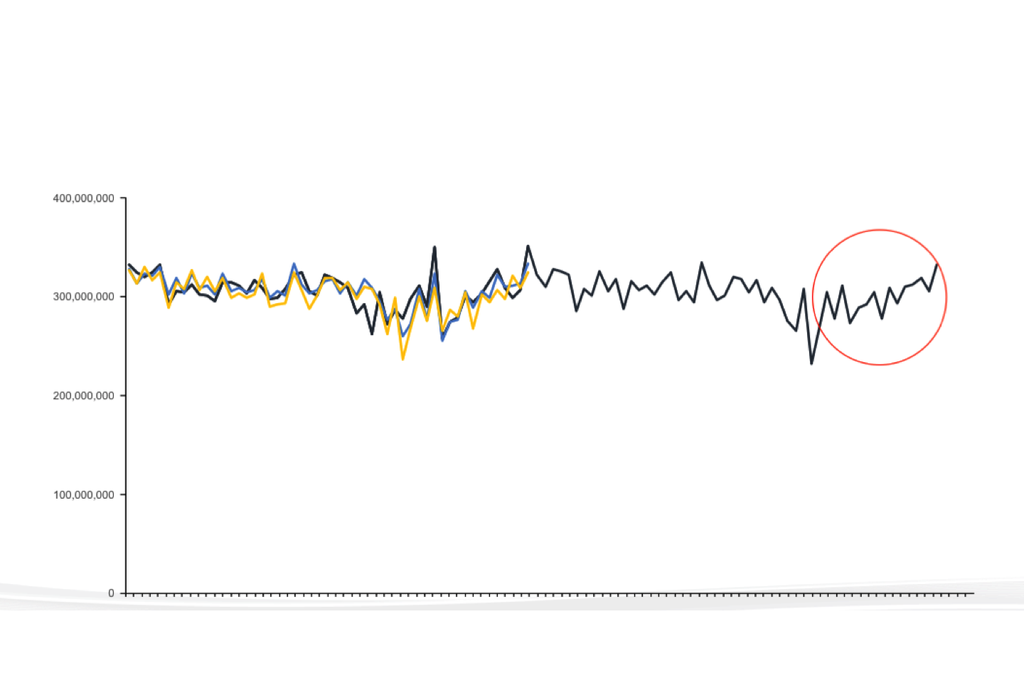

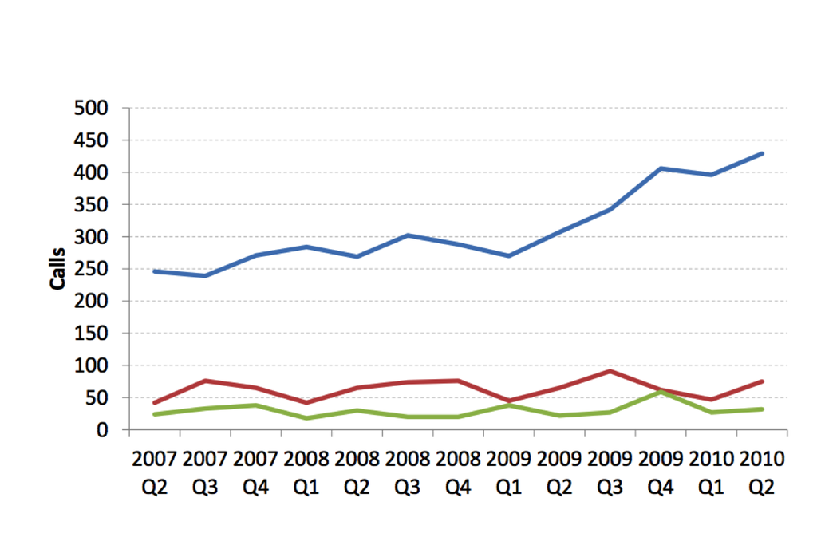

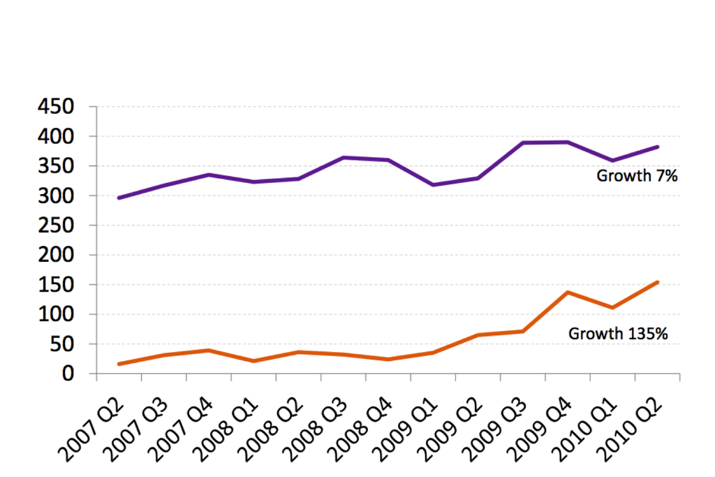

## Problems

## Problems

1. All styled differently. We need to edit every plot individually.

## Problems

1. All styled differently. We need to edit every plot individually.
2. No documentation on how to replicate.

## Problems

1. All styled differently. We need to edit every plot individually.
2. No documentation on how to replicate.
3. It takes time to replicate.

## Instead? R!

## R:

```
function darkhorse_histogram(x_data, x_var, x_breaks, title,
                             y_breaks, col="#E69F00") {
    ggplot(x_data, aes(x_var)) +
        geom_bar(fill=col, aes(y=(..count..)/sum(..count..))) +
        geom_hline(yintercept= 0, colour=col) +
        darkhorse_theme() +
        ggtitle(title) +
        theme(axis.line.x = element_blank(),
            axis.line.y = element_blank(),
            axis.ticks = element_blank()) +
        scale_y_continuous(breaks=y_breaks, labels=percent) +
        ylab("") +
        geom_hline(yintercept=y_breaks[2:length(y_breaks)], color="white") +
        scale_x_continuous(breaks=x_breaks)
}
```

## Best practice charts

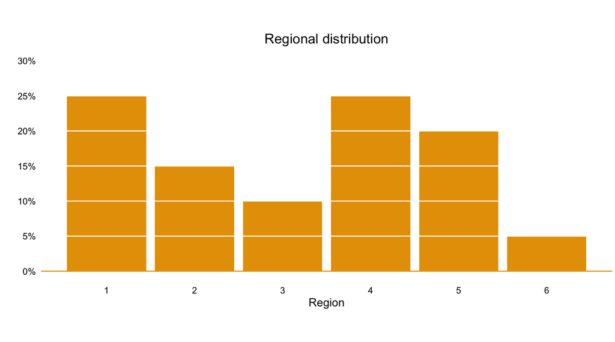

## Best practice charts

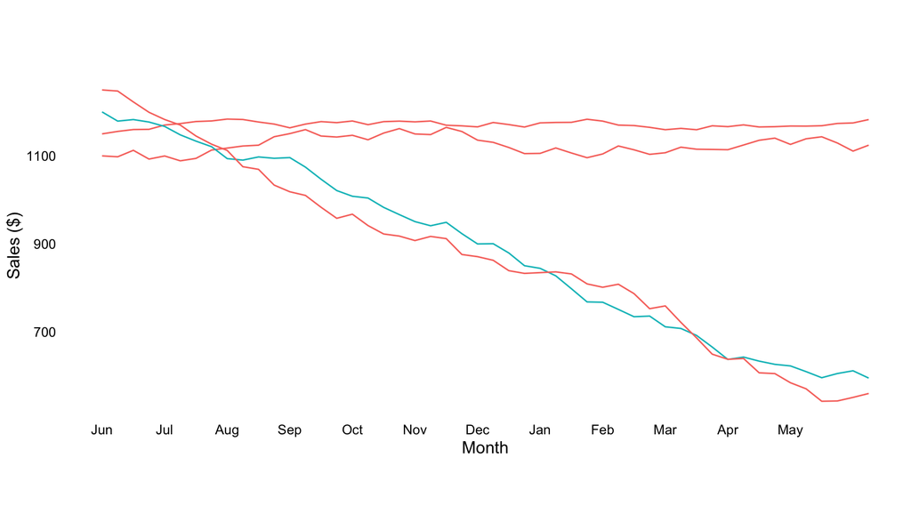

## What we did:

## What we did:

1. Use RMarkdown to write template ("best practice") slides.

## What we did:

1. Use RMarkdown to write template ("best practice") slides.
2. Make the slides accessible to the company (we used Git + Bitbucket).

## What we did:

1. Use RMarkdown to write template ("best practice") slides.
2. Made the slides accessible to the company (we used Git + Bitbucket).
3. Made it easy to run in other environments (we used installation scripts & Docker)

## What we did:

1. Use RMarkdown to write template ("best practice") slides.
2. Made the slides accessible to the company (we used Git + Bitbucket).
3. Made it easy to run in other environments (we used installation scripts & Docker)
4. Iterate (we used Git).

## Lessons

1. Make it good.

## Lessons

1. Make it good.
2. Make it easy.

## Lessons

1. Make it good.
2. Make it easy.
3. Make it profitable.